# last.fm User Analysis

Amanda Stott, PhD

6-13-2018

Attribute Information:

Last.fm is a music website, founded in the United Kingdom in 2002. It has claimed over 40 million active users based in more than 190 countries. This contains the friendship network crawled in December 2010 by Megan Kearl (makearl@asu.edu). Thanks Megan!

Dataset via http://socialcomputing.asu.edu/datasets/Last.fm

Data Set Information – 2 files are included:

1. nodes.csv

– it’s the file of all the users. This file works as a dictionary of all the users in this data set. It’s useful for fast reference. It contains of all the node ids used in the dataset.

2. edges.csv

– this is the friendship network among the users. The friends are represented using edges. Here is an example.

1,2

This means user with id “1” is friend with user id “2”.

-. Basic statistics Number of Nodes: 108,493 Number of Edges: 5,115,300

## Problem Statement: Using the Last.fm Dataset, derive relationships between nodes and edges to determine the interaction pattern of users within the network. Using the interaction pattern, construct a model to identify the number of associations and number of impressions. *** In a real-world scenario, the next step would be to correlate user data with consumer data via Oracle Data Cloud or similar.

### Steps in the Analysis:

1.) Determine how we want to graphically represent the data.

*** For this dataset, given that we have a social network with nodes and edges, I selected a tree representation to map the community network relationships between nodes and edges. ***

2.) Clean and simplifying the data to produce meaningful content that is easy to interpret and comprehend - This includes applying appropriate models to fit the data, when appropriate.

*** As the dataset contains far too many associations to meaningfully represent via a tree diagram, I decided to simplify using a binary adjacency matrix. ***

### Steps in Community Clustering Associations Determination:

a.) Generate random graphs according to the G(n,m) Erdos-Renyi model via the igraph package in R b.) Simplify by removing repeat values c.) Calculate the adjacency matrix for each of the random graphs simplified in step b – Keep only random graph matrix elements equal to 1 d.) Take the cross-product of the adjacency matrix calculated in c with each simplified random graph in b e.) Make a matrix of eigenvalues determined in d and create a tree from this data using the igraph make_tree funciton – The multiplicity of the eigenvalues are equal to the number of connected components f.) Plot the tree to determine network clustering associations

3.) Analyze the output - Extract relevant information and present results.

4.) Validate output via hypothesis testing - plot the statistical distributon of the row norms of the matrix used to determine the associations and impressions data - Accept the hypothesis that the number of degrees of freedom in the system between associations and impressions is valid if the P-value is >= 0.95 using a normal distribution. If the hypothesis is accepted, use the degrees of freedome to test advertising campaign reach by correlating user IDs provided in node and edge data with Oracle Data Cloud user behaviour.

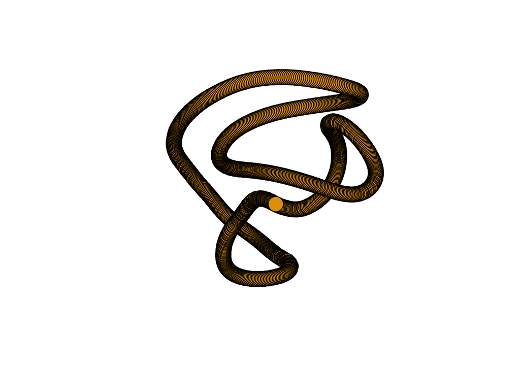

Plot the ring diagram of user group associations - increasing the value this time to 10 group associations and 30 group impressions - this produces ovbious smoothing, but not quite a ring yet.

[figure not shown]

Plot the ring diagram of user group associations - increasing the value this time to 12 group associations and 32 group impressions - this produces even more smoothing, and a nearly symmetrical structure.

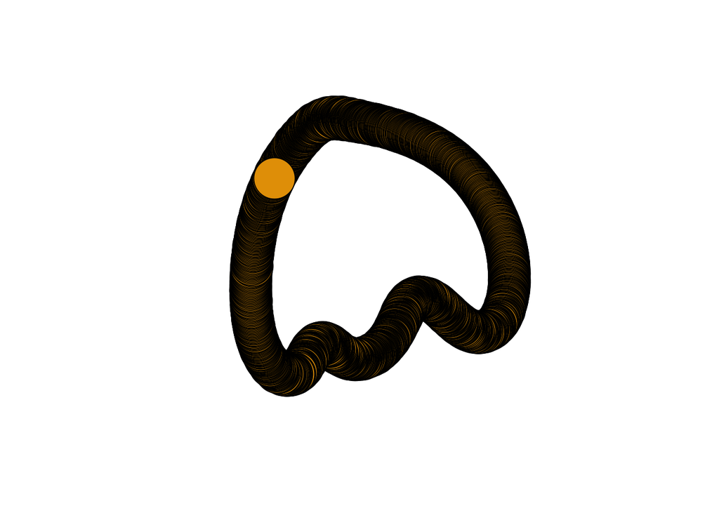

Plot the ring diagram of user group associations - increasing the value this time to 17 group associations and 37 group impressions produces a circular ring.

[figure not shown]

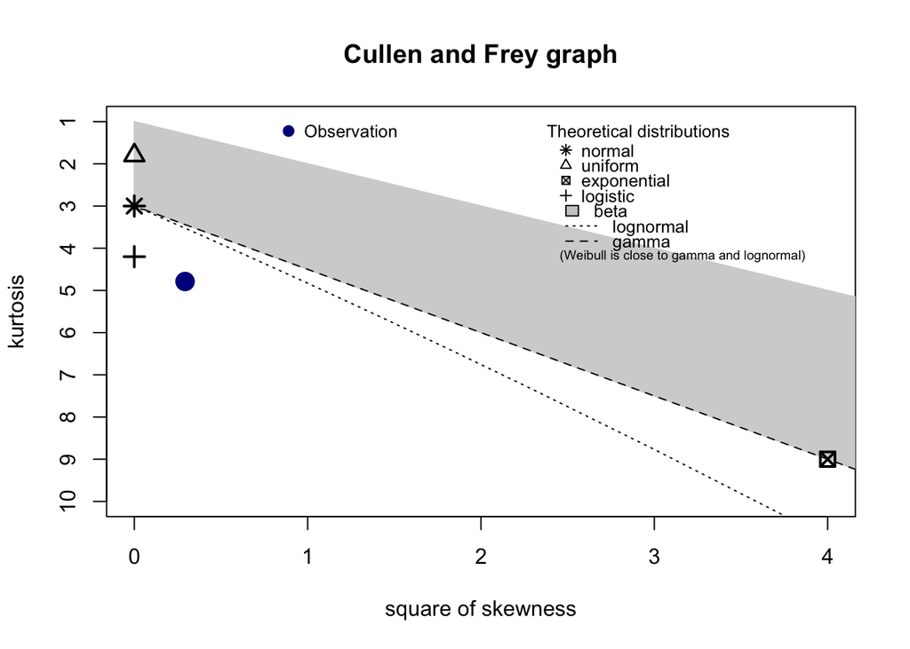

```
## summary statistics
## ------
## min:  -1.322508   max:  1.353434
## median:  0.1044703
## mean:  0.2038242
## estimated sd:  0.7238271
## estimated skewness:  -0.5410209
## estimated kurtosis:  4.788516
```

```
## Fitting of the distribution ' norm ' by maximum likelihood
## Parameters:
##       estimate Std. Error
## mean 0.2038242  0.2171481
## sd   0.6866826  0.1535454
```

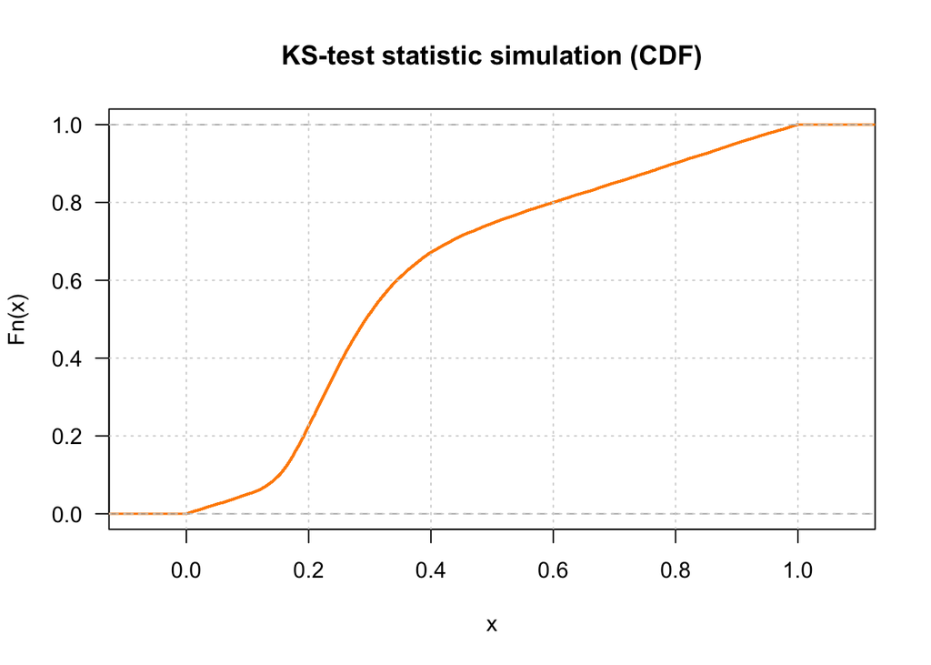

```
##
##  Two-sample Kolmogorov-Smirnov test
##
## data:  my_fit_dist$x and my_fit_dist$y
## D = 0.16667, p-value = 0.9715
## alternative hypothesis: two-sided
```

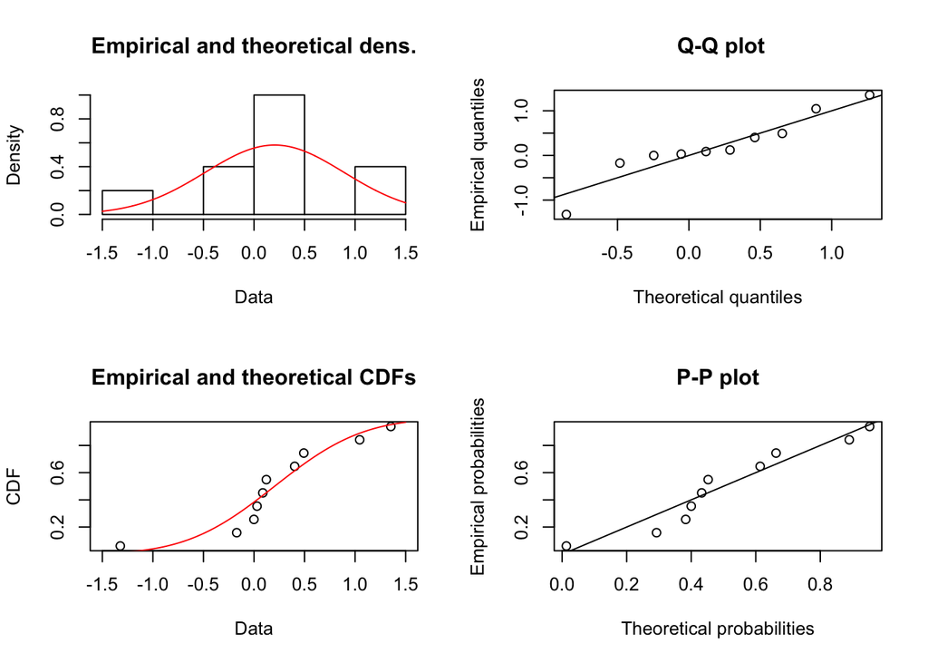